# DS344 Sentiment Analysis

Hannah Quass & Jack Grimston

2023-10-24

## 1.1 Problem and data description

#### - Scraped data from Pam Golding’s website. We restricted our project to only include properties in the Cape Winelands area

#### - 443 observations of property listings, with variables for the number of bedrooms, bathrooms, garages, and parking spaces, as well the text description of the house

#### - Main exploration is to find whether the sentiment of a house’s description can predict the price it is listed for.

## 1.2 Data processing

### 1.2.1 Data Preparation

- Tokenize and clean text data
- Get sentiments using afinn sentiment lexicon

### 1.2.2 Data Exploration

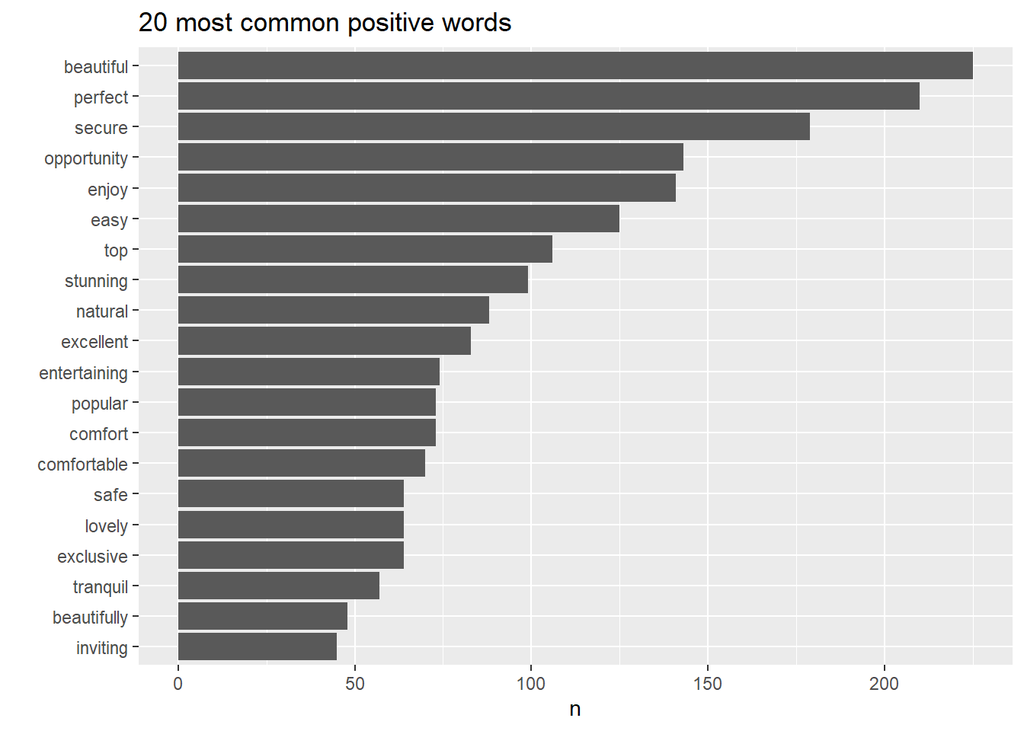

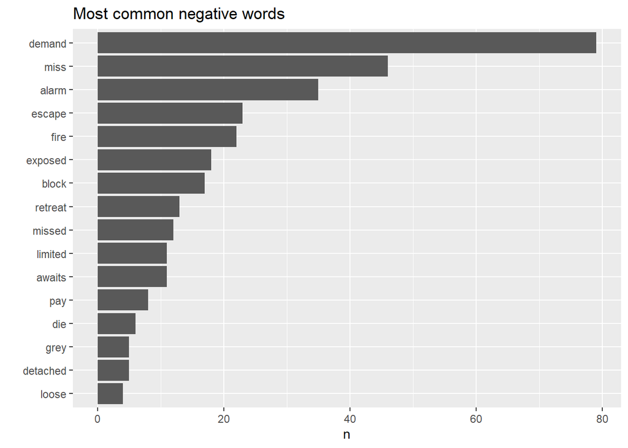

#### Investigating individual negative words

##### “Die”

The negative word “die” being detected is actually from “Die Laan” and “Die Boord”, two Afrikaans place names in Stellenbosch - we need to change it to have a neutral sentiment

##### “Miss”

The negative word “miss” is most often used in the context: “Don’t miss the opportunity to own this amazing house”

##### “Fire” and “alarm”

The context of these words is describing a house that has a fire alarm!

We need to change the sentiments of these words listed above to take their context into consideration in the analysis.

#### Investigating individual positive words

##### And changing the sentiments of words not in the afinn lexicon

Drawing a random sample of descriptions to read through, I found that there were many words that clearly had a positive sentiment that the afinn lexicon did not label as such. I manually assigned sentiments to these words. Some examples include: “sublime” “exquisite” “captivating” “quality” “luxury” etc.

The assignment of these sentiment scores is clearly limited because of my subjective choices, but the subjective scores I defined still carry more meaning that a sentiment of zero would have.

### 1.2.3 Sentiment negation

#### Observing use cases of the word “miss”:

- 15: Don’t miss the opportunity …
- 23: Don’t miss your chance…
- 30: Don’t miss out on this opportunity.
- 48: Don’t miss out on this amazing opportunity…
- 271: Don’t miss out on this incredible opportunity…

So what we see is that the word “miss” preceded by the word “don’t” is actually a negated bigram, and I need to account for it when doing sentiment negation.

For sentiment negation the basic process was:

- Tokenise the text data by bigrams
- Get the sentiment of each word in the bigram
- Change the sentiment of the second word in a bigram by multiplying by -1 if the first word in the bigram is a negation word
- Negation words used: “not” “never” “without” “can’t” “won’t”

#### Observe how the sentiments have changed after negation

Sentiments after negation

| id | price | word1 | word2 | sentiment1 | sentiment2 |
| --- | --- | --- | --- | --- | --- |
| 5 | 25,000,000 | without | doubt | 0 | 1 |
| 10 | 22,000,000 | never | tired | 0 | 2 |
| 39 | 13,500,000 | not | disappoint | 0 | 2 |
| 68 | 9,995,000 | not | escape | 0 | 1 |
| 143 | 5,495,000 | not | miss | 0 | 2 |
| 307 | 2,750,000 | not | miss | 0 | 2 |
| 336 | 2,375,000 | not | hesitate | 0 | 2 |

- Finally, put the separated bigrams back together and update the sentiments of words that have been changed after negation.

#### Comparing how aggregate sentiment has changed after negations and manually adjusting the sentiment of individual words

Change in aggregate sentiment after processing

| id | old sentiment | new sentiment |
| --- | --- | --- |
| 1 | 6 | 23 |
| 2 | 16 | 35 |
| 3 | 26 | 45 |
| 4 | 10 | 23 |
| 5 | 12 | 26 |
| 6 | 47 | 65 |
| 7 | 36 | 40 |

We see that our basic sentiment analysis has significantly changed the aggregate sentiment of each house description.

## 1.3 Modelling

### 1.3.1 Developing features from the sentiments of house descriptions

#### Predictors:

#### - weighted aggregate sentiment

#### - number of positive words per description

#### - number of negative words per description

#### - proportion of positive words per description

#### - proportion of negative words per description

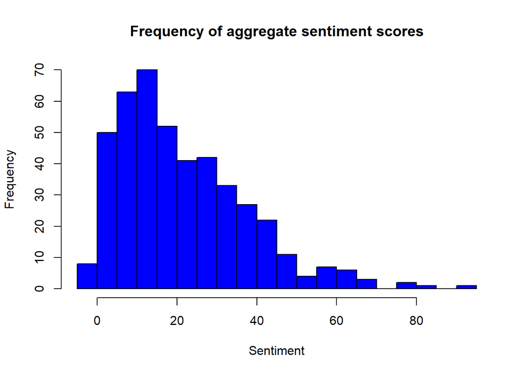

Descriptions with a negative aggregate sentiment

| id | net_sentiment |
| --- | --- |
| 205 | -1 |
| 397 | -1 |

- Note that only two descriptions have a negative aggregate sentiment (mistake in code that was handed in)

#### Next we weight each house’s sentiment score with the number of words in the description.

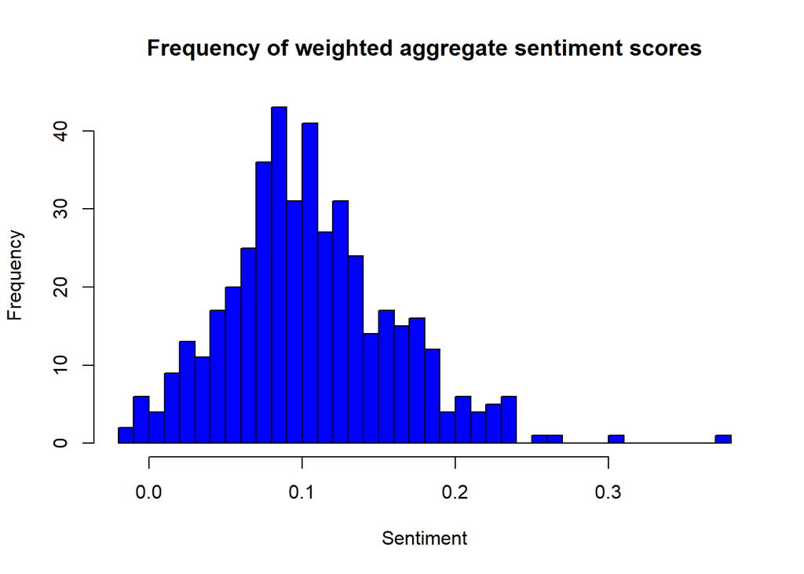

### Observing the correlations between variables

#### - Weakest correlation is with the number of negative words

#### - Strongest correlation is with the length of the description

Correlation between price and features

| Feature name | correlation with price |
| --- | --- |
| num_pos_words | 0.1879581 |
| num_neg_words | 0.0383105 |
| pos_proportion | -0.0897769 |
| neg_proportion | -0.0568840 |
| weighted_sentiment | 0.0733802 |
| description_length | 0.2768616 |

### Plotting the relationship between price and different sentiment predictors

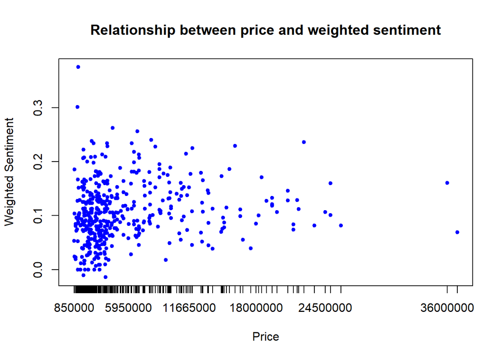

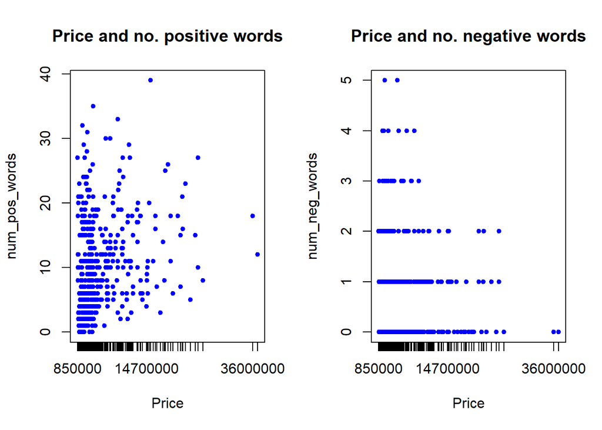

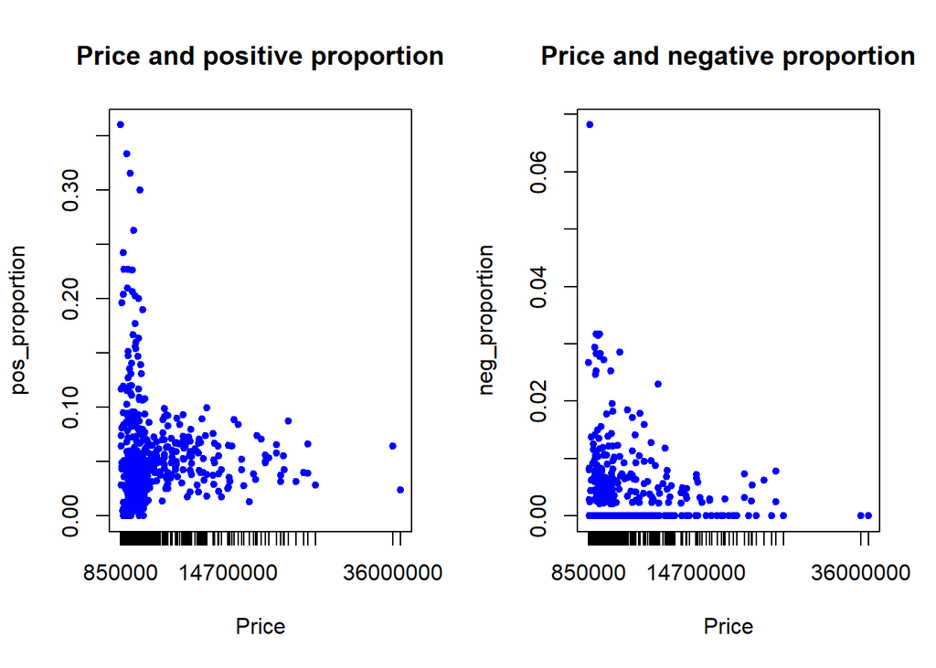

### 1.3.2 Investigating features in different price brackets

Features per price range

| Price range | mean no. of positive words | mean no. of negative words | mean positive proportion | mean negative proportion | mean weighted sentiment | mean description length |
| --- | --- | --- | --- | --- | --- | --- |
| < 3m | 8.801205 | 0.8132530 | 0.0676560 | 0.0051065 | 0.0968027 | 169.6024 |
| 3m-6m | 8.965035 | 0.6083916 | 0.0521275 | 0.0031093 | 0.1010252 | 196.7483 |
| 6m-9m | 12.192308 | 0.8269231 | 0.0557395 | 0.0037634 | 0.1311256 | 226.4038 |
| 9m-12m | 13.818182 | 0.5757576 | 0.0522269 | 0.0029946 | 0.1222424 | 260.1212 |
| 12m-15m | 11.944444 | 0.6666667 | 0.0462047 | 0.0023347 | 0.1106372 | 271.1667 |
| > 15m | 15.193548 | 0.5806452 | 0.0494657 | 0.0018826 | 0.1165538 | 305.9032 |

### 1.3.3 Linear regression using only sentiment features

[output not shown]

#### The regression coefficients sorted according to absolute value

```
##     pos_proportion     neg_proportion weighted_sentiment        (Intercept)
##       32076373.072       28104419.190        4028346.900        3081674.098
##      num_neg_words      num_pos_words description_length
##         477468.832         271644.027           8635.727
```

### 1.3.4 Linear regression using all features

```
##
## Call:
## lm(formula = price ~ ., data = reg_features)
##
## Residuals:
##       Min        1Q    Median        3Q       Max
## -35983018  -1920288   -106221   1675579  33737087
##
## Coefficients:
##                      Estimate Std. Error t value Pr(>|t|)
## (Intercept)        -3705466.1  1030882.8  -3.594 0.000363 ***
## weighted_sentiment  8391996.3  4152984.8   2.021 0.043927 *
## num_pos_words         92282.3    61500.8   1.501 0.134216
## num_neg_words       -393640.4   423667.5  -0.929 0.353344
## pos_proportion     -8096444.1  8273075.3  -0.979 0.328302
## neg_proportion     39908558.9 59062280.6   0.676 0.499592
## description_length    10006.7     3598.9   2.780 0.005666 **
## bedrooms            -515770.4   251116.5  -2.054 0.040587 *
## bathrooms           1970431.6   238618.9   8.258 1.84e-15 ***
## erf_size               2644.5      153.1  17.268  < 2e-16 ***
## garages              543317.2   206044.5   2.637 0.008669 **
## parkings              87692.4   118056.9   0.743 0.458009
## ---
## Signif. codes:  0 '***' 0.001 '**' 0.01 '*' 0.05 '.' 0.1 ' ' 1
##
## Residual standard error: 4479000 on 431 degrees of freedom
## Multiple R-squared:  0.6778, Adjusted R-squared:  0.6695
## F-statistic: 82.41 on 11 and 431 DF,  p-value: < 2.2e-16
```

#### The regression coefficients sorted according to absolute value

```
##     neg_proportion weighted_sentiment     pos_proportion        (Intercept)
##       39908558.856        8391996.290        8096444.142        3705466.123
##          bathrooms            garages           bedrooms      num_neg_words
##        1970431.601         543317.228         515770.351         393640.435
##      num_pos_words           parkings description_length           erf_size
##          92282.274          87692.440          10006.684           2644.495
```

## 1.4 Conclusions

#### - Sentiment of a description is not a good predictor for price!

#### - Further area of investigation: embedding numeric features into sentiment and text analysis